# Reproducible Research Peer 1

Setting working directory

```r
setwd("C:/Users/ddddd/Reproducible peer 1")
```

Loading the activity dataset “activity.csv” using “read.csv”

```r
dataset<-read.csv("activity.csv", header = T, sep = ",", stringsAsFactors = F)
```

Get a summary of number of steps, date and interval

```r
dataset$date <- as.Date(dataset$date, "%Y-%m-%d")
summary(dataset)
```

```
##      steps             date               interval
##  Min.   :  0.00   Min.   :2012-10-01   Min.   :   0.0
##  1st Qu.:  0.00   1st Qu.:2012-10-16   1st Qu.: 588.8
##  Median :  0.00   Median :2012-10-31   Median :1177.5
##  Mean   : 37.38   Mean   :2012-10-31   Mean   :1177.5
##  3rd Qu.: 12.00   3rd Qu.:2012-11-15   3rd Qu.:1766.2
##  Max.   :806.00   Max.   :2012-11-30   Max.   :2355.0
##  NA's   :2304
```

Checking for the dimensions of the activity dataset

```r
dim(dataset)
```

```
## [1] 17568     3
```

Install the required packages

install.packages(“dplyr”)

install.packages(“ggplot2”)

Loading the library library(dplyr)

library(ggplot2)

Now, start calculating the required results as gven in this assignment

# Que 1 What is the mean total number of steps taken per day?

Part 1.Calculating the total number of steps taken per day Here, the missing values are not included

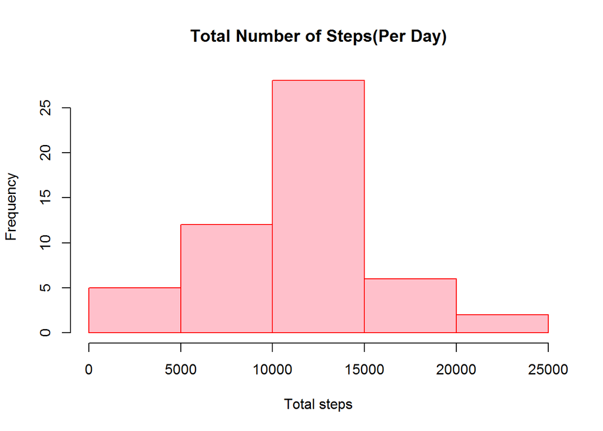

```r
totalstep <- aggregate(steps ~ date, dataset, sum)
hist(totalstep$steps, main = paste("Total Number of Steps(Per Day)"), col="pink",border="red",xlab="Total steps")
```

part 2 Calculating the mean and median of the total number of steps taken per day

1.Calculating mean

```r
totalstepmean <- mean(totalstep$steps)
totalstepmean
```

```
## [1] 10766.19
```

2.Calculating median

```r
totalstepmedian <- median(totalstep$steps)
totalstepmedian
```

```
## [1] 10765
```

# Que 2. What is the average daily activity ?

Part 1.Making the time series plot

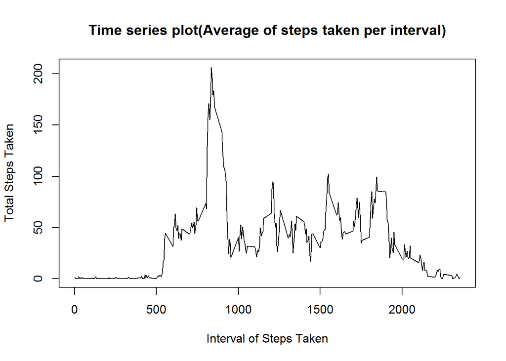

```r
totalstepint <- aggregate(steps ~ interval, dataset, mean)
plot(totalstepint$interval,totalstepint$steps, type="l", xlab="Interval of Steps Taken", ylab="Total Steps Taken",main="Time series plot(Average of steps taken per interval)")
```

Part 2. Determining the interval, having the maximum number of steps

```r
Maximumstepsint <- totalstepint[which.max(totalstepint$steps),1]
Maximumstepsint
```

```
## [1] 835
```

# Que 3. Impute of fill the missing values(NAs)

Part 1.Calculating the sum of total missing values(NAs)

```r
Sum_Missing_Values <- sum(!complete.cases(dataset))
Sum_Missing_Values
```

```
## [1] 2304
```

Part 2. Fill in the missing values(NAs) in the dataset

```r
avgstepformissing <- aggregate(steps ~ interval, data = dataset, FUN = mean)
missingvaluefilling <- numeric()
```

Now,apply looping and fill the missing values (NAs)

```r
for (i in 1:nrow(dataset)) {
  vari1 <- dataset[i, ]
    if (is.na(vari1$steps)) {
        steps <- subset(avgstepformissing, interval == vari1$interval)$steps
    } else {
        steps <- vari1$steps
    }

   missingvaluefilling <- c(missingvaluefilling, steps)
}
```

Table of data after filling missing values(NAs)

```r
table(missingvaluefilling)
```

[output not shown]

[output cut: 566 more lines]

First value

```r
head(missingvaluefilling)
```

```
## [1] 1.7169811 0.3396226 0.1320755 0.1509434 0.0754717 2.0943396
```

Last value

```r
tail(missingvaluefilling)
```

```
## [1] 2.6037736 4.6981132 3.3018868 0.6415094 0.2264151 1.0754717
```

Part 3.Making a new dataset(dataset1) which also includes all the missing values(NAs) along with original data

```r
dataset1 <- dataset
dataset1$steps <- missingvaluefilling
```

Part 4.Making a histogram of total steps taken per day including the missing values(NAs)

```r
totalstepwithNA <- aggregate(steps ~ date, data = dataset1, sum, na.rm = TRUE)
```

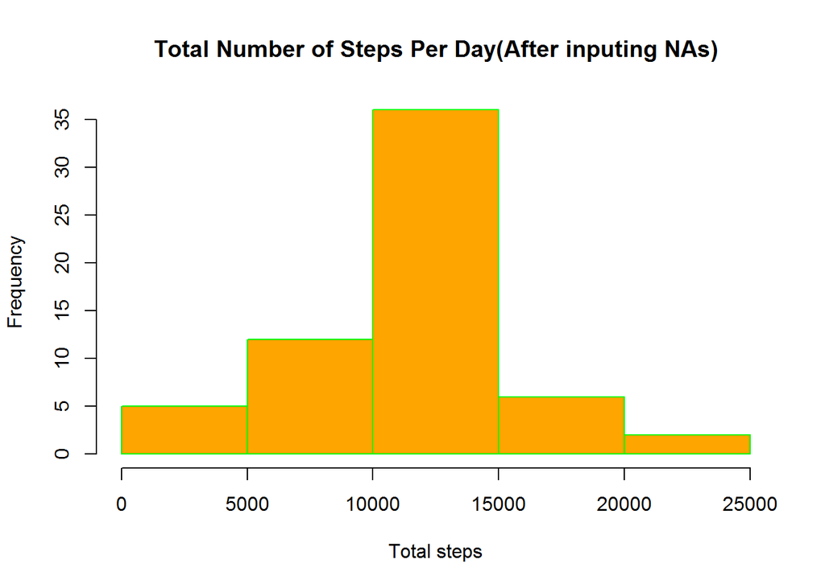

```r
#Plotting the histogram
hist(totalstepwithNA$steps, main = paste("Total Number of Steps Per Day(After inputing NAs)"), col="orange",border="green", xlab="Total steps")
```

Part 5.calculating the mean and median total number of steps taken per day

1.calculating mean

```r
totalstepwithNA_mean <- mean(totalstepwithNA$steps)
totalstepwithNA_mean
```

```
## [1] 10766.19
```

2.calculating median

```r
totalstepwithNA_median <- median(totalstepwithNA$steps)
totalstepwithNA_median
```

```
## [1] 10766.19
```

Part 6. Comparing the mean and median of both the plots above in which one doesn’t have missing values while the another one includes all the missing values

1.Diffrence of mean in both plots

```r
Diffrence_mean <- totalstepwithNA_mean - totalstepmean
Diffrence_mean
```

```
## [1] 0
```

2.Diffrence of median in both plots

```r
Diffrence_median <- totalstepwithNA_median - totalstepmedian
Diffrence_median
```

```
## [1] 1.188679
```

# Que 4.what are the differences in activity between weekdays and weekends?

Loading the library lattice for using the lattice graph or xyplot. This plot helps to display bivariate plot and here the plot shows the #number of steps taken in weekdays and weekends together in one plot.

```r
library(lattice)
```

Part 1. As given on courera assignment , this step includes creating a new factor

```r
Totalweekdays <- c("Monday", "Tuesday", "Wednesday", "Thursday",
              "Friday")
dataset1$dow = as.factor(ifelse(is.element(weekdays(as.Date(dataset1$date)),Totalweekdays), "weekdays", "weekends"))
totalstepwithNA <- aggregate(steps ~ interval + dow, dataset1, mean)
```

Part2.Ploting the result which shows the average number of steps taken per interval both in the weekends and the weekdays

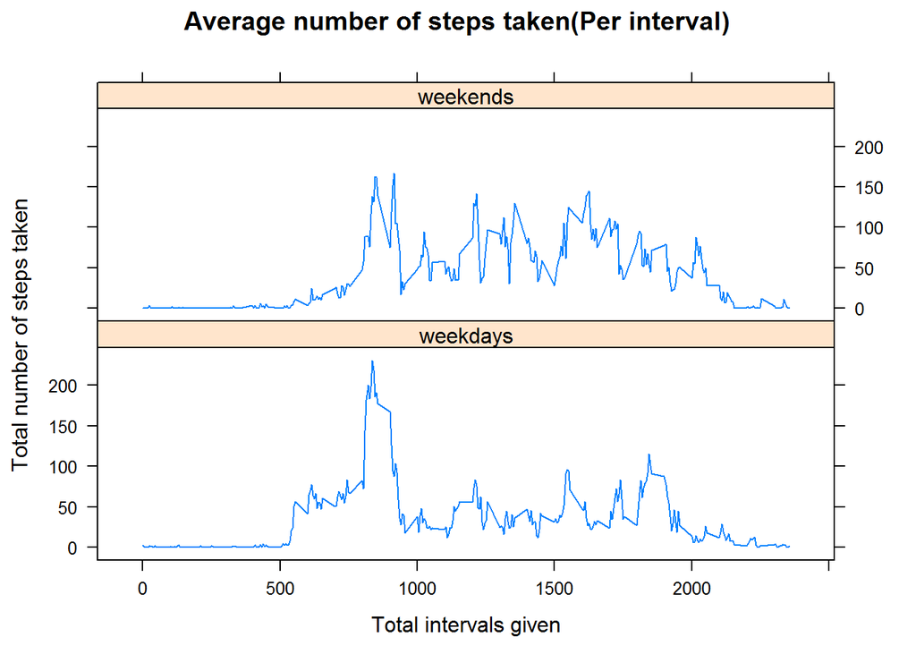

```r
xyplot(totalstepwithNA$steps ~ totalstepwithNA$interval|totalstepwithNA$dow, main="Average number of steps taken(Per interval)",xlab="Total intervals given", ylab="Total number of steps taken",layout=c(1,2), type="l")
```